# BIOL 607 Homework 2

Nina McDonnell

9/25/2020

## 1. Some Data with Flippers

### 1a. Load the library palmerpenguins after installing it.

```r
#load palmerpenguins library
library(palmerpenguins)
```

### 1b. Show the head of the dataset penguins

```r
data(penguins)
head(penguins) #head penguins dataset to see columns
```

```
## # A tibble: 6 x 8
##   species island bill_length_mm bill_depth_mm flipper_length_… body_mass_g sex
##   <fct>   <fct>           <dbl>         <dbl>            <int>       <int> <fct>
## 1 Adelie  Torge…           39.1          18.7              181        3750 male
## 2 Adelie  Torge…           39.5          17.4              186        3800 fema…
## 3 Adelie  Torge…           40.3          18                195        3250 fema…
## 4 Adelie  Torge…           NA            NA                 NA          NA <NA>
## 5 Adelie  Torge…           36.7          19.3              193        3450 fema…
## 6 Adelie  Torge…           39.3          20.6              190        3650 male
## # … with 1 more variable: year <int>
```

### 1c. What do you learn by using str() and summary() on penguins?

From str() and summary(), I can see that the data is a 344 row x 8 column tibble including factor, numeric, and integer vectors. Summary gives totals of counts of data points from each species, island, and year (factors), and describes the variance of numeric and integer values, such as beak and flipper measurements and mass.

```r
str(penguins)   #The data is a 344 row x 8 column tibble including factor, numeric, and integer vectors.
```

```
## tibble [344 × 8] (S3: tbl_df/tbl/data.frame)
##  $ species          : Factor w/ 3 levels "Adelie","Chinstrap",..: 1 1 1 1 1 1 1 1 1 1 ...
##  $ island           : Factor w/ 3 levels "Biscoe","Dream",..: 3 3 3 3 3 3 3 3 3 3 ...
##  $ bill_length_mm   : num [1:344] 39.1 39.5 40.3 NA 36.7 39.3 38.9 39.2 34.1 42 ...
##  $ bill_depth_mm    : num [1:344] 18.7 17.4 18 NA 19.3 20.6 17.8 19.6 18.1 20.2 ...
##  $ flipper_length_mm: int [1:344] 181 186 195 NA 193 190 181 195 193 190 ...
##  $ body_mass_g      : int [1:344] 3750 3800 3250 NA 3450 3650 3625 4675 3475 4250 ...
##  $ sex              : Factor w/ 2 levels "female","male": 2 1 1 NA 1 2 1 2 NA NA ...
##  $ year             : int [1:344] 2007 2007 2007 2007 2007 2007 2007 2007 2007 2007 ...
```

```r
summary(penguins)    #Gives totals of counts for each species, island, and year (factors), and describes variance of numeric and integer values- such as beak and flipper measurements and mass.
```

```
##       species          island    bill_length_mm  bill_depth_mm
##  Adelie   :152   Biscoe   :168   Min.   :32.10   Min.   :13.10
##  Chinstrap: 68   Dream    :124   1st Qu.:39.23   1st Qu.:15.60
##  Gentoo   :124   Torgersen: 52   Median :44.45   Median :17.30
##                                  Mean   :43.92   Mean   :17.15
##                                  3rd Qu.:48.50   3rd Qu.:18.70
##                                  Max.   :59.60   Max.   :21.50
##                                  NA's   :2       NA's   :2
##  flipper_length_mm  body_mass_g       sex           year
##  Min.   :172.0     Min.   :2700   female:165   Min.   :2007
##  1st Qu.:190.0     1st Qu.:3550   male  :168   1st Qu.:2007
##  Median :197.0     Median :4050   NA's  : 11   Median :2008
##  Mean   :200.9     Mean   :4202                Mean   :2008
##  3rd Qu.:213.0     3rd Qu.:4750                3rd Qu.:2009
##  Max.   :231.0     Max.   :6300                Max.   :2009
##  NA's   :2         NA's   :2
```

### 1d. What are the quantiles of bill depth across the whole data set? What do those quantiles mean?

The 0%, 25%, 50%, 75%, and 100% quantities for bill depth are 13.1, 15.6, 17.3, 18.7, 21.5, respectively.

This means that 100% of penguins have bill lengths between 13.1 and 21.5 mm. 50% of the data points for bill depth are greater than 17.3mm and 25% of data points are greater than 18.7mm (75th percentile).

```r
quantile(penguins$bill_depth_mm, na.rm=TRUE) #quantiles for bill depth from the penguins data set, NA values were removed.
```

```
##   0%  25%  50%  75% 100%
## 13.1 15.6 17.3 18.7 21.5
```

## 2. What’s here? Let’s use dplyr!

### 2a. If I have a vector, c(1,4,7,NA,9), what is its mean? Note, the NA is going to cause a problem. Look at ?mean to learn how to solve it.

The mean of the vector will be “NA”, unless na.rm =TRUE. **Once corrected, the mean is 5.25.**

```r
my_vec <- c(1,4,7,NA,9)  #created vector to test how NA value will affect mean().
mean(my_vec) #testing mean with problematic NA value
```

```
## [1] NA
```

```r
?mean #I will need to use na.rm=TRUE to calculate the mean without the NA value.
mean(my_vec, na.rm = TRUE) #the mean of the vector
```

```
## [1] 5.25
```

### 2b. What is the mean, sd, and median of body mass across the data set? Note, these NAs are going to cause some problems, so you might need to look at the documentation for the relevant functions.

The mean of body mass is 4202g

The median of body mass is 4050g

The standard deviation of body mass is 802g

```r
penguins %>%
  summarize(mean_body_mass=mean(body_mass_g, na.rm=TRUE), #mean, median, and sd of body mass for penguins. NA values removed.
  median_body_mass=median(body_mass_g, na.rm=TRUE),
  sd_body_mass=sd(body_mass_g, na.rm=TRUE))
```

```
## # A tibble: 1 x 3
##   mean_body_mass median_body_mass sd_body_mass
##            <dbl>            <dbl>        <dbl>
## 1          4202.             4050         802.
```

### 2c. Repeat 2b, but, show us how these quantities differ by species.

```r
penguins %>%
  group_by(species) %>% #group penguins by species
  summarize(avg_mass_species=mean(body_mass_g, na.rm=TRUE), #mean, median, and sd of body mass for species groups. NA values removed.
  med_mass_species=median(body_mass_g, na.rm=TRUE),
  sd_mass_species=sd(body_mass_g, na.rm=TRUE)) %>%
  ungroup() #ungroup dataset to avoid problems
```

```
## # A tibble: 3 x 4
##   species   avg_mass_species med_mass_species sd_mass_species
##   <fct>                <dbl>            <dbl>           <dbl>
## 1 Adelie               3701.             3700            459.
## 2 Chinstrap            3733.             3700            384.
## 3 Gentoo               5076.             5000            504.
```

### 2d. Repeat 2c, but just for Biscoe island. What is different in the results?

The results only include Adelie and Gentoo penguins because there were no Chinstrap penguins sampled from Biscoe island. Average mass was slightly greater for Adelie penguins on Biscoe island than across the whole sample, but average Gentoo mass was the same (once we get to 3b, we can see that this is because Gentoo are only found on Biscoe island). Median and standard deviation of mass were also greater for Adelie penguins on Biscoe island than Adelie accross all locations.

```r
penguins %>%
  filter(island=="Biscoe") %>% #adding Biscoe island as a filter to examine only data points from this location
  group_by(species) %>% #grouping Biscoe island penguins by species
  summarize(avg_mass_species=mean(body_mass_g, na.rm=TRUE), #calculating mean, median and sd of body mass for each species group (NAs removed).
            med_mass_species=median(body_mass_g, na.rm=TRUE),
            sd_mass_species=sd(body_mass_g, na.rm=TRUE)) %>%
  ungroup() #ungroup dataset to avoid problems
```

```
## # A tibble: 2 x 4
##   species avg_mass_species med_mass_species sd_mass_species
##   <fct>              <dbl>            <dbl>           <dbl>
## 1 Adelie             3710.             3750            488.
## 2 Gentoo             5076.             5000            504.
```

### 2e. Make a species-island column in penguins using paste(). This is an awesome function that takes multiple strings, and slams them together using the argument sep = to define how the string should be combined. Try out paste(“Hello”, “Goodbye”, sep = “!”) to see how it works. Have the two be separated by _.

```r
paste("Hello", "Goodbye", sep ="!") #testing paste() with hello and goodbye
```

```
## [1] "Hello!Goodbye"
```

```r
#creating new data frame from penguins with a species_island column
new_penguins <- penguins %>%
  mutate(species_island=paste(species, island, sep="_"))

str(new_penguins) #str data frame to examine vectors
```

```
## tibble [344 × 9] (S3: tbl_df/tbl/data.frame)
##  $ species          : Factor w/ 3 levels "Adelie","Chinstrap",..: 1 1 1 1 1 1 1 1 1 1 ...
##  $ island           : Factor w/ 3 levels "Biscoe","Dream",..: 3 3 3 3 3 3 3 3 3 3 ...
##  $ bill_length_mm   : num [1:344] 39.1 39.5 40.3 NA 36.7 39.3 38.9 39.2 34.1 42 ...
##  $ bill_depth_mm    : num [1:344] 18.7 17.4 18 NA 19.3 20.6 17.8 19.6 18.1 20.2 ...
##  $ flipper_length_mm: int [1:344] 181 186 195 NA 193 190 181 195 193 190 ...
##  $ body_mass_g      : int [1:344] 3750 3800 3250 NA 3450 3650 3625 4675 3475 4250 ...
##  $ sex              : Factor w/ 2 levels "female","male": 2 1 1 NA 1 2 1 2 NA NA ...
##  $ year             : int [1:344] 2007 2007 2007 2007 2007 2007 2007 2007 2007 2007 ...
##  $ species_island   : chr [1:344] "Adelie_Torgersen" "Adelie_Torgersen" "Adelie_Torgersen" "Adelie_Torgersen" ...
```

## 3. A Little Light Plotting

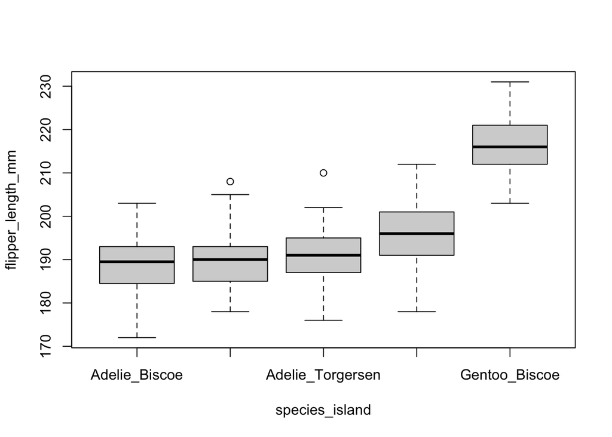

```r
boxplot(flipper_length_mm~species_island, data=new_penguins) #boxplot with species_island on x-axis and flipper length on y-axis
```

## *Extra credit*

```r
new_penguins2 <-penguins %>%
  mutate(species_island=paste(species, island, sep= "\n")) #trying paste() with \n to see what happens

str(new_penguins2) #str data frame to examine vectors
```

```
## tibble [344 × 9] (S3: tbl_df/tbl/data.frame)
##  $ species          : Factor w/ 3 levels "Adelie","Chinstrap",..: 1 1 1 1 1 1 1 1 1 1 ...
##  $ island           : Factor w/ 3 levels "Biscoe","Dream",..: 3 3 3 3 3 3 3 3 3 3 ...
##  $ bill_length_mm   : num [1:344] 39.1 39.5 40.3 NA 36.7 39.3 38.9 39.2 34.1 42 ...
##  $ bill_depth_mm    : num [1:344] 18.7 17.4 18 NA 19.3 20.6 17.8 19.6 18.1 20.2 ...
##  $ flipper_length_mm: int [1:344] 181 186 195 NA 193 190 181 195 193 190 ...
##  $ body_mass_g      : int [1:344] 3750 3800 3250 NA 3450 3650 3625 4675 3475 4250 ...
##  $ sex              : Factor w/ 2 levels "female","male": 2 1 1 NA 1 2 1 2 NA NA ...
##  $ year             : int [1:344] 2007 2007 2007 2007 2007 2007 2007 2007 2007 2007 ...
##  $ species_island   : chr [1:344] "Adelie\nTorgersen" "Adelie\nTorgersen" "Adelie\nTorgersen" "Adelie\nTorgersen" ...
```

### 3b. Show the relationship between average flipper length and average body mass by species and island. What do you see?

In the plot of average flipper length ~ average body mass for species_island, I can see that the three Adelie penguin points are clustered towards the lower left. Chinstrap penguins have greater average flipper length than Adelie from all islands, but similar body mass (Chinstrap have longer flippers relative to body mass than Adelie). Gentoo penguins have much greater body mass and flipper length than the other two species. There may be a positive relationship between body mass and flipper length for penguins, but it is difficult to tell from these data because there are only 5 samples of average flipper length and body mass for species_island groups, and the single Gentoo data point heavily influences the appearance of a positive relationship. Additionally, I would not consider the three Adelie points to be independent if comparing values across species, since they are from a single species.

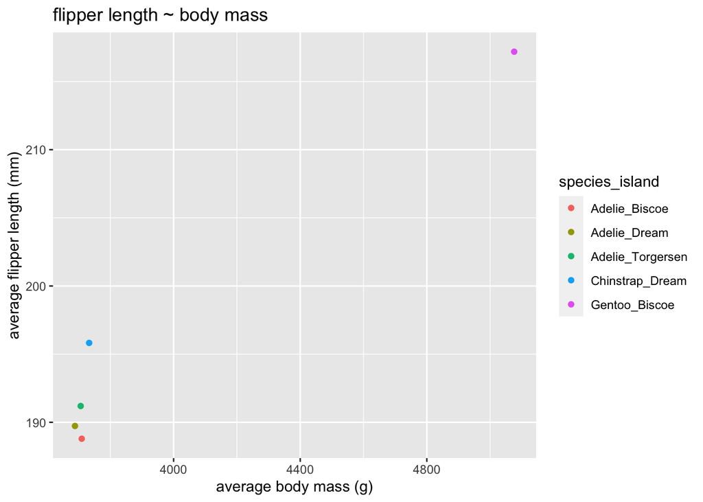

```r
#making new data frame with flipper length and body mass grouped by species_island and then averaged for each group
new_penguins3 <- new_penguins %>%
  group_by(species_island) %>% #grouping penguins by species_island
  select(species_island, flipper_length_mm, body_mass_g) %>% #selecting only the three variables of interest for the data frame
  summarise(average_flipper_length_mm=mean(flipper_length_mm, na.rm = TRUE),
            average_body_mass_g=mean(body_mass_g, na.rm=TRUE)) %>% #calculating averages for flipper length and body mass for each species_island group
  ungroup() %>% #ungroup dataset to avoid problems
  head() #check that data structure includes the desired elements

#I was not sure how to display the species_island data points in such a way that they could be easily distinguished from one another using base plots, so here is ggplot2:
penguin_plot <- ggplot(data=new_penguins3, aes(x=average_body_mass_g, y=average_flipper_length_mm, color=species_island)) +
  geom_point() +
  ylab("average flipper length (mm)")+
  xlab("average body mass (g)")+
  ggtitle("flipper length ~ body mass")

penguin_plot
```

### 3c. Interesting. What if you had made the same plot with the whole dataset? What do you see? Is there anything that could clarify the result any more? Think about it - lots of possible right answers here.

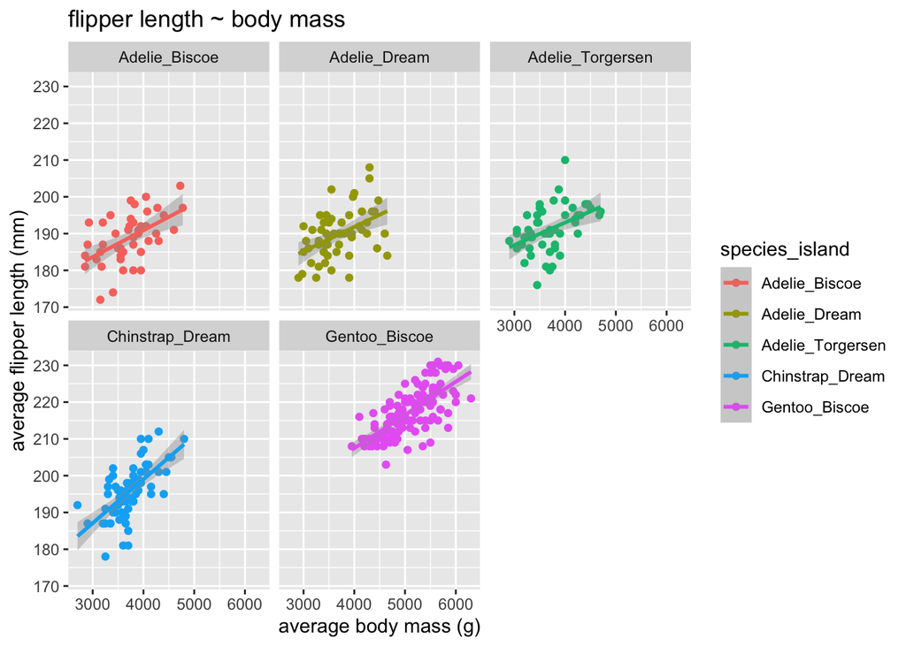

```r
new_penguins4 <- new_penguins %>% #made new data frame with individual mass and flipper length data points (not averaged) for each species_island group (now showing the whole data set, but still grouped)
  group_by(species_island) %>% #grouping penguins by species_island
  select(species_island, flipper_length_mm, body_mass_g) %>% #selecting only variables of interest for the dataframe
  ungroup() #ungroup dataset to avoid problems

#I used ggplot 2 to plot flipper length ~ mass for each species_island.
penguin_plot2 <- ggplot(data=new_penguins4, aes(x=body_mass_g, y=flipper_length_mm, color=species_island)) +
  geom_point() +
  ylab("average flipper length (mm)")+
  xlab("average body mass (g)")+
  ggtitle("flipper length ~ body mass")+
  facet_wrap(vars(species_island))+ #facet_wrap to make separate plots for each species_island
  stat_smooth(method=lm) #adding lm line to help visualize patterns

penguin_plot2
```

After viewing plots of flipper length ~ mass for individual penguins from the whole dataset, I can see that there is a positive realtionship between the two variables within each group (species_island) sampled. However, this does not clarify the potential relationship between flipper length and body mass across species from 3b. There may be many other species that do not fit the trend of greater species body size = greater species flipper length (say, a species with very short flippers and large body mass), even if the two traits do have a positive relationship within their own populations. Understanding the relationship between the traits within populations does not shed any light on the pattern observed across species. All we can say is that within each species_island group that was sampled, there was a positive association between body mass and flipper length.

I proceeded to explore the relationship within species…

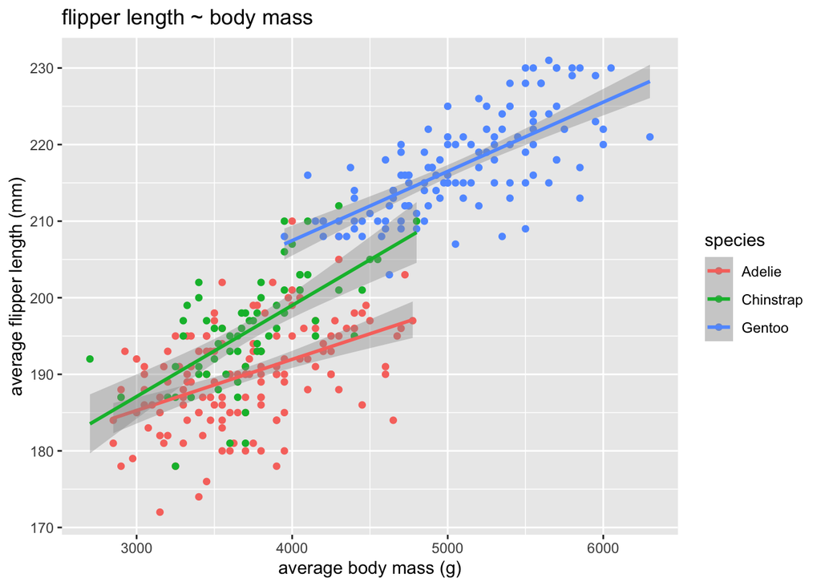

```r
new_penguins5 <- new_penguins %>% #made new data frame with mass and flipper length for each species (whole data set, now only grouped by species)
  group_by(species) %>% #grouping penguins by species
  select(species, flipper_length_mm, body_mass_g)%>% #selecting only variables of interest for the dataframe
  ungroup() #ungroup dataset to avoid problems

penguin_plot3 <- ggplot(data=new_penguins5, aes(x=body_mass_g, y=flipper_length_mm, color=species)) +
  geom_point() +
  ylab("average flipper length (mm)")+
  xlab("average body mass (g)")+
  ggtitle("flipper length ~ body mass")+
  stat_smooth(method=lm)

penguin_plot3
```

The above plot is more useful for understanding the relationship between flipper length and body mass for the three species. We can see that there is a positive association between the two variables for all species sampled. This is more informative than the first plot because it shows the trends within species, and less redundant than the second plot, which shows the three island samples for Adelie separately.

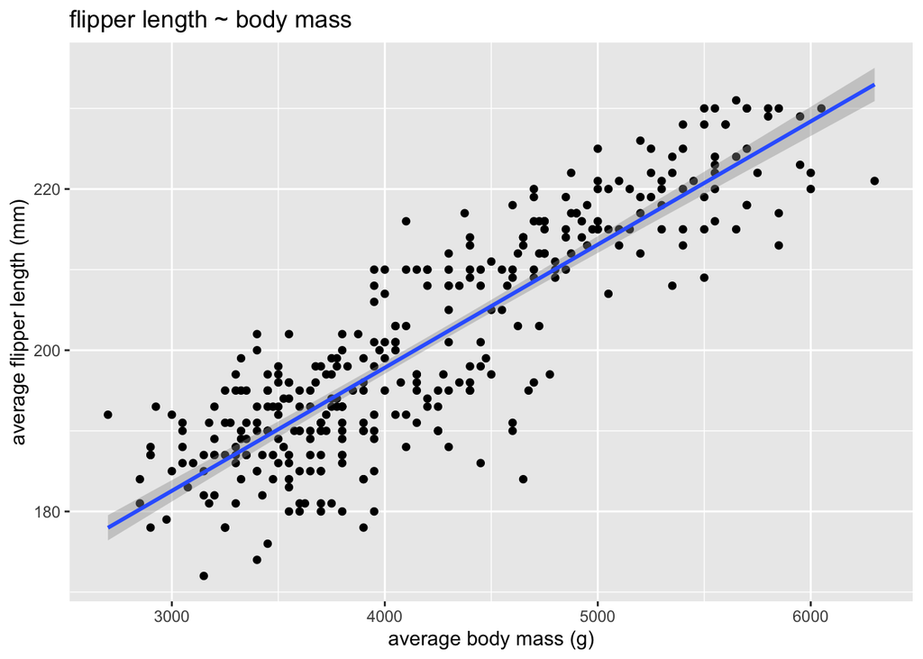

```r
new_penguins6 <- new_penguins %>% #dataframe with no grouping
  select(species, flipper_length_mm, body_mass_g)%>% #selecting only variables of interest for the dataframe
  ungroup() #ungroup dataset to avoid problems

penguin_plot4 <- ggplot(data=new_penguins6, aes(x=body_mass_g, y=flipper_length_mm)) +
  geom_point() +
  ylab("average flipper length (mm)")+
  xlab("average body mass (g)")+
  ggtitle("flipper length ~ body mass")+
  stat_smooth(method=lm)

penguin_plot4
```

Lastly, I tried removing all groupings to observe flipper length and body mass across a pool of the individual penguins sampled. I think that this is less helpful than the plots grouped by species because it does not convey that the positive relationship was observed in three separate species (3 independent samples). However, it does depict the relationship more generally.

## 4. Let’s get ready to simulate

### 4a. Grab the values for bill_length_mm for Gentoo penguins in Biscoe Island and put it into an object. Note, the dplyr function pull() is kinda cool, as if you apply it to a data frame, it will pull out a vector from a column of interest. Try mtcars %>% pull(mpg). Kinda cool. Might help you here.

```r
mtcars %>% #testing pull() on mtcars
  pull(mpg)
```

```
##  [1] 21.0 21.0 22.8 21.4 18.7 18.1 14.3 24.4 22.8 19.2 17.8 16.4 17.3 15.2 10.4
## [16] 10.4 14.7 32.4 30.4 33.9 21.5 15.5 15.2 13.3 19.2 27.3 26.0 30.4 15.8 19.7
## [31] 15.0 21.4
```

```r
gentoo_biscoe_bill <- pull(penguins %>%  #pulling vector from penguins dataset
                             filter(species=="Gentoo") %>%  #only want Gentoo
                             filter(island=="Biscoe") %>%  #only want Biscoe
                             select(bill_length_mm)) #selecting bill_length as the variable of interest
gentoo_biscoe_bill
```

```
##   [1] 46.1 50.0 48.7 50.0 47.6 46.5 45.4 46.7 43.3 46.8 40.9 49.0 45.5 48.4 45.8
##  [16] 49.3 42.0 49.2 46.2 48.7 50.2 45.1 46.5 46.3 42.9 46.1 44.5 47.8 48.2 50.0
##  [31] 47.3 42.8 45.1 59.6 49.1 48.4 42.6 44.4 44.0 48.7 42.7 49.6 45.3 49.6 50.5
##  [46] 43.6 45.5 50.5 44.9 45.2 46.6 48.5 45.1 50.1 46.5 45.0 43.8 45.5 43.2 50.4
##  [61] 45.3 46.2 45.7 54.3 45.8 49.8 46.2 49.5 43.5 50.7 47.7 46.4 48.2 46.5 46.4
##  [76] 48.6 47.5 51.1 45.2 45.2 49.1 52.5 47.4 50.0 44.9 50.8 43.4 51.3 47.5 52.1
##  [91] 47.5 52.2 45.5 49.5 44.5 50.8 49.4 46.9 48.4 51.1 48.5 55.9 47.2 49.1 47.3
## [106] 46.8 41.7 53.4 43.3 48.1 50.5 49.8 43.5 51.5 46.2 55.1 44.5 48.8 47.2   NA
## [121] 46.8 50.4 45.2 49.9
```

### 4b. Use replicate() to calculate the standard error of the mean 10 times. Use a formula! Don’t forget that NA values shouldn’t be included!

SE= 0.276759

```r
replicate(n=10, sd(gentoo_biscoe_bill, na.rm = TRUE)/sqrt(length(gentoo_biscoe_bill))) #calculated se 10 times, using formula: SD/sqrt(n). NA values removed.
```

```
##  [1] 0.276759 0.276759 0.276759 0.276759 0.276759 0.276759 0.276759 0.276759
##  [9] 0.276759 0.276759
```

### 4c. Use map_df() to create a data frame with the mean and sd of different sample sizes using the first 5 through 100 values (so, n = 5:100 - smallest sample size will have the values 1-5). Make sure the sample size is included in the final data frame.

```r
gentoo_dataframe <- map_df(5:100, ~data.frame(  #using first 5-100 values
  sample_size= .x,  #add sample size as comumn in dataframe
  mean = mean(gentoo_biscoe_bill[1:.x]), #calculate mean
  sd = sd (gentoo_biscoe_bill[1:.x]))) #calculate SD
```

### 4d. Plot the relationship between sample size and SD and sample size versus SE of the mean. What difference do you see and why? Note, you’ll need to create a column for SE here!

The positions of points on the two plots look the same, but the y-axis values are smaller for SE than for SD. This is because the SE is being calculated from the SD, but there is less variability between repeated samples than is observed within a given sample.

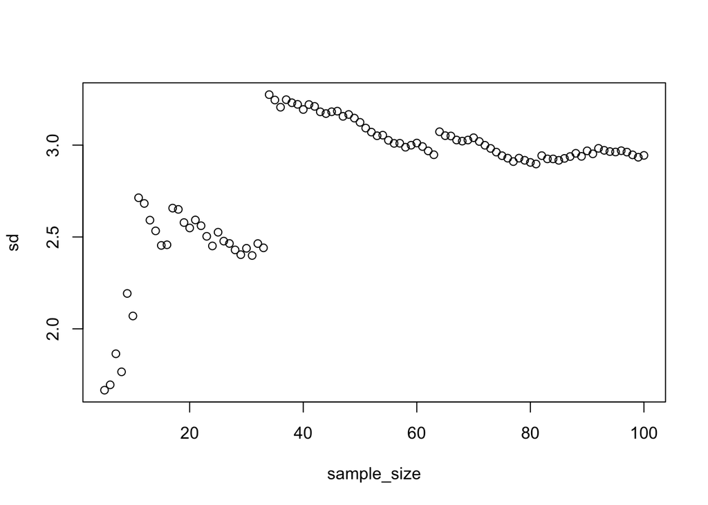

```r
gentoo_dataframe2 <- gentoo_dataframe %>% #making new data frame with column for SE
  mutate(se= sd/sqrt(length(gentoo_biscoe_bill))) #mutate to add SE column to data frame (sd/sqrt(n))

plot(sd~sample_size, data = gentoo_dataframe2) #plot sd~ sample size
```

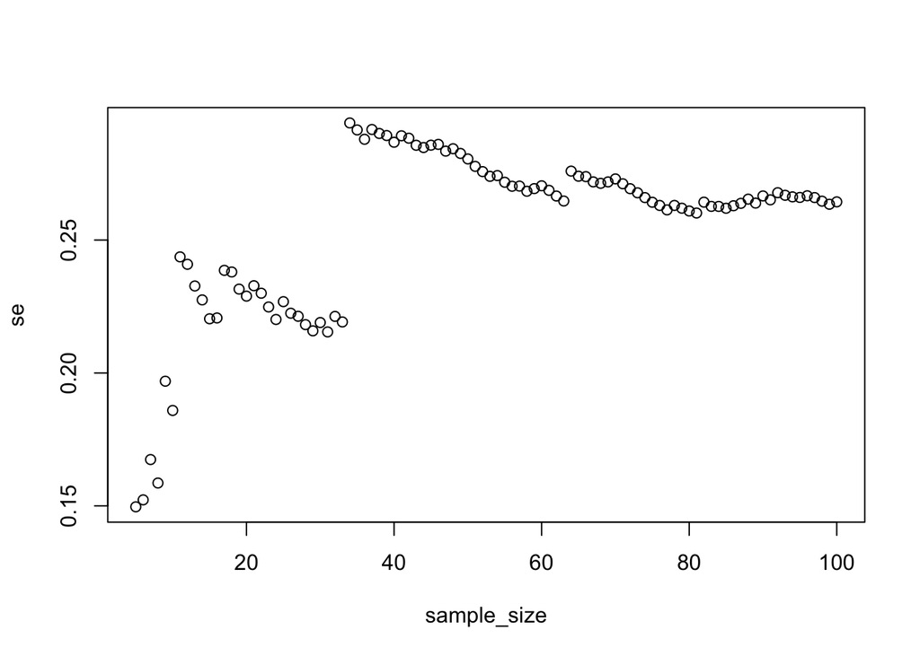

```r
plot(se~sample_size, data = gentoo_dataframe2) #plot se~ sample size, looks the same except for y-axis values
```

## *Extra credit:* submitted via GitHub.

### Repository: https://github.com/ninamcdonnell/biol607_mcdonnell/tree/master/homework/homework_markdown